# Raster teaching demo

Casey O’Hara

8/18/2021

```r
### Set up packages and data from earlier episodes:
library(raster)
library(tidyverse)
```

### Context:

- Find the height of trees in a portion of the Harvard Forest LTER site using lidar digital surface and digital terrain models.

### Objectives:

- Gain familiarity with raster spatial data format
- Perform simple spatial analysis using raster math
- Write results to GeoTIFF
- Plot results using base plot and ggplot

[figure not shown]

```r
knitr::include_graphics('lidar_pic.png')
```

Load in the rasters from Github repo

```r
# DSM data for Harvard Forest
dsm <- raster('data/dsm_harv_crop.tif')
# DTM data for Harvard Forest
dtm <- raster('data/dtm_harv_crop.tif')
```

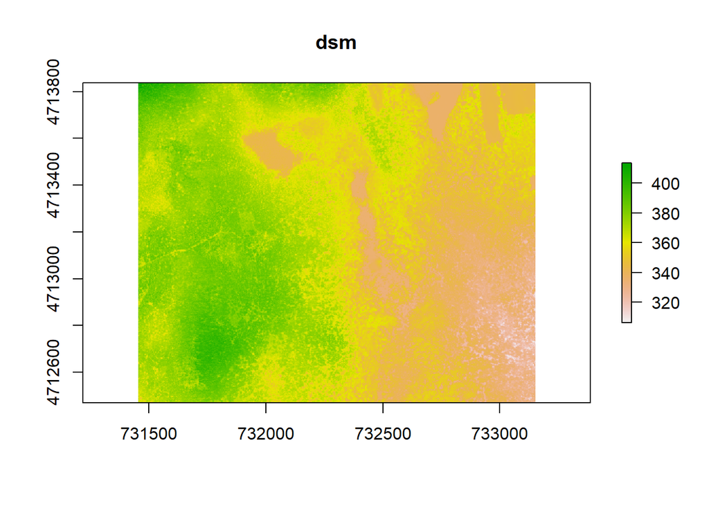

```r
plot(dsm, main = 'dsm')
```

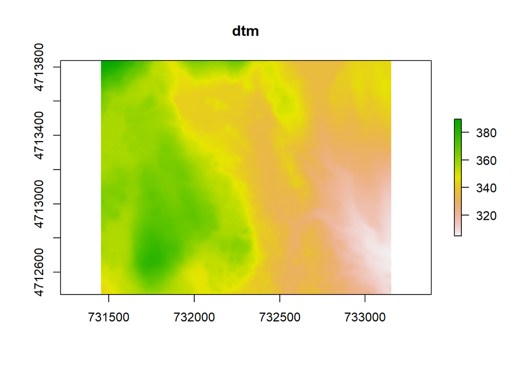

```r
plot(dtm, main = 'dtm')
```

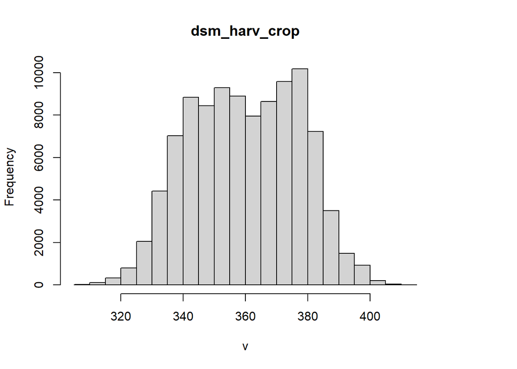

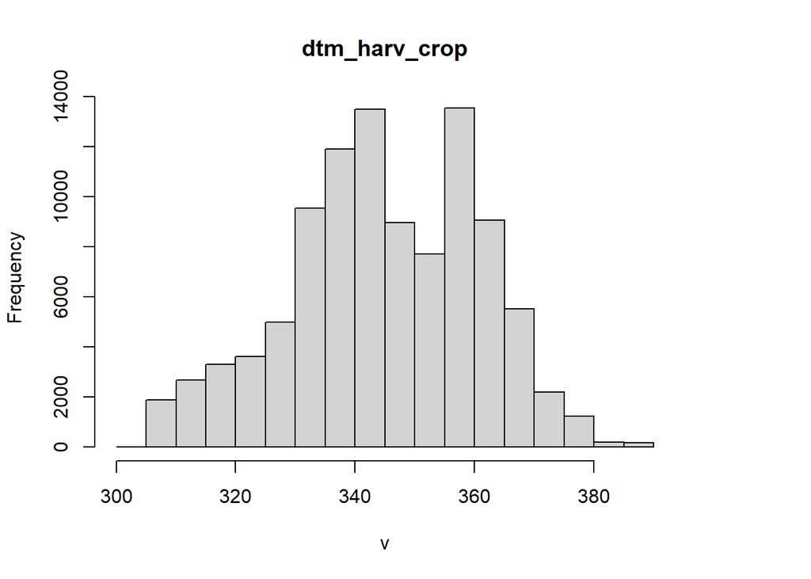

```r
hist(dsm); hist(dtm)
```

A raster is a set of values, arranged into a grid, with some geospatial information attached to that grid to locate it in space.

Examine the attributes of the two data rasters:

```r
dsm; dtm
```

```
## class      : RasterLayer
## dimensions : 456, 566, 258096  (nrow, ncol, ncell)
## resolution : 3, 3  (x, y)
## extent     : 731453, 733151, 4712470, 4713838  (xmin, xmax, ymin, ymax)
## crs        : +proj=utm +zone=18 +datum=WGS84 +units=m +no_defs
## source     : dsm_harv_crop.tif
## names      : dsm_harv_crop
## values     : 306.2211, 413.6033  (min, max)
```

```
## class      : RasterLayer
## dimensions : 456, 566, 258096  (nrow, ncol, ncell)
## resolution : 3, 3  (x, y)
## extent     : 731453, 733151, 4712470, 4713838  (xmin, xmax, ymin, ymax)
## crs        : +proj=utm +zone=18 +datum=WGS84 +units=m +no_defs
## source     : dtm_harv_crop.tif
## names      : dtm_harv_crop
## values     : 304.7883, 389.63  (min, max)
```

We will use “raster math” to calculate the CHM model. Raster math is like vector math, because raster values are basically vectors in disguise:

```r
x <- 1:10
x^2 + 5
```

```
##  [1]   6   9  14  21  30  41  54  69  86 105
```

```r
log(x)
```

```
##  [1] 0.0000000 0.6931472 1.0986123 1.3862944 1.6094379 1.7917595 1.9459101
##  [8] 2.0794415 2.1972246 2.3025851
```

```r
x <- values(dsm)
y <- values(dtm)
head(x); head(y)
```

```
## [1] 406.5356 407.6678 413.0455 410.3022 407.6833 403.1344
```

```
## [1] 389.3644 389.1522 388.8644 388.8922 389.1022 389.1711
```

```r
head(x - y)
```

```
## [1] 17.17111 18.51553 24.18109 21.41000 18.58112 13.96332
```

Just as you can do math on a vector, you can do math on rasters:

```r
dsm
```

```
## class      : RasterLayer
## dimensions : 456, 566, 258096  (nrow, ncol, ncell)
## resolution : 3, 3  (x, y)
## extent     : 731453, 733151, 4712470, 4713838  (xmin, xmax, ymin, ymax)
## crs        : +proj=utm +zone=18 +datum=WGS84 +units=m +no_defs
## source     : dsm_harv_crop.tif
## names      : dsm_harv_crop
## values     : 306.2211, 413.6033  (min, max)
```

```r
dsm * 3.281 ### convert elevation in meters to feet
```

```
## class      : RasterLayer
## dimensions : 456, 566, 258096  (nrow, ncol, ncell)
## resolution : 3, 3  (x, y)
## extent     : 731453, 733151, 4712470, 4713838  (xmin, xmax, ymin, ymax)
## crs        : +proj=utm +zone=18 +datum=WGS84 +units=m +no_defs
## source     : memory
## names      : dsm_harv_crop
## values     : 1004.711, 1357.033  (min, max)
```

```r
log(dsm)
```

```
## class      : RasterLayer
## dimensions : 456, 566, 258096  (nrow, ncol, ncell)
## resolution : 3, 3  (x, y)
## extent     : 731453, 733151, 4712470, 4713838  (xmin, xmax, ymin, ymax)
## crs        : +proj=utm +zone=18 +datum=WGS84 +units=m +no_defs
## source     : memory
## names      : layer
## values     : 5.724307, 6.024907  (min, max)
```

Let’s calculate a canopy height model using raster math, by subtracting the terrain model from the surface model:

```r
chm <- dsm - dtm
chm
```

```
## class      : RasterLayer
## dimensions : 456, 566, 258096  (nrow, ncol, ncell)
## resolution : 3, 3  (x, y)
## extent     : 731453, 733151, 4712470, 4713838  (xmin, xmax, ymin, ymax)
## crs        : +proj=utm +zone=18 +datum=WGS84 +units=m +no_defs
## source     : memory
## names      : layer
## values     : 0, 30.94446  (min, max)
```

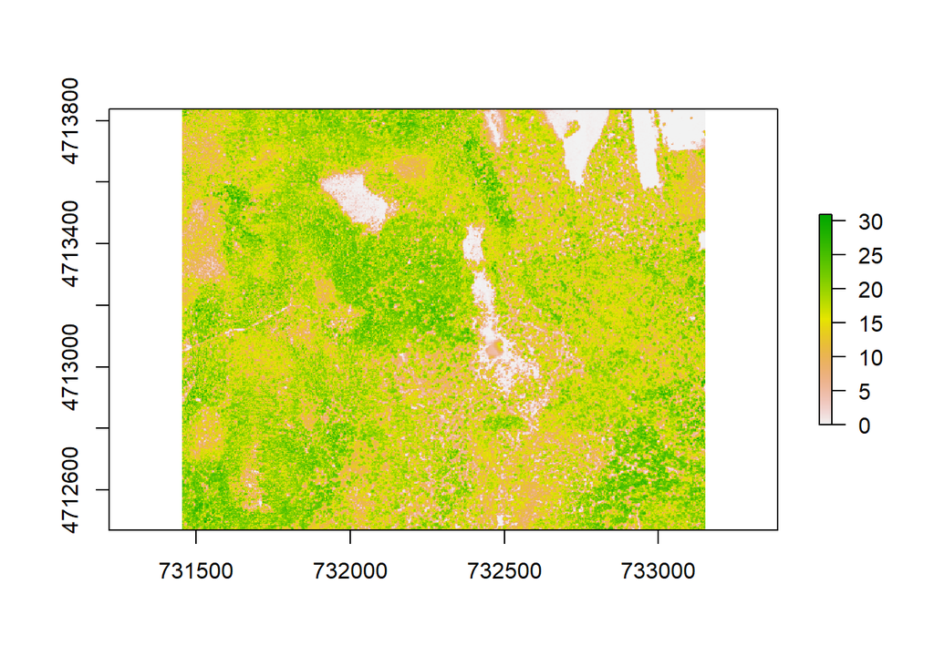

```r
plot(chm)
```

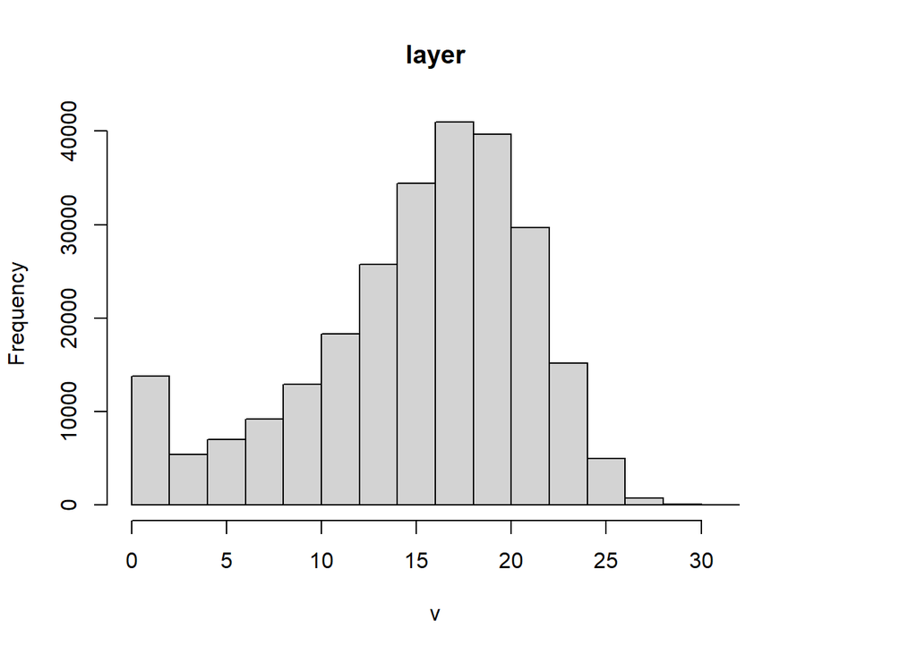

```r
hist(chm)
```

Let’s use `writeRaster` to write our results to a file

```r
# ?writeRaster
writeRaster(chm, filename = 'chm_harv.tif',
            format = 'GTiff',
            overwrite = TRUE)
```

To plot using `ggplot()`, need to convert the raster to a data frame:

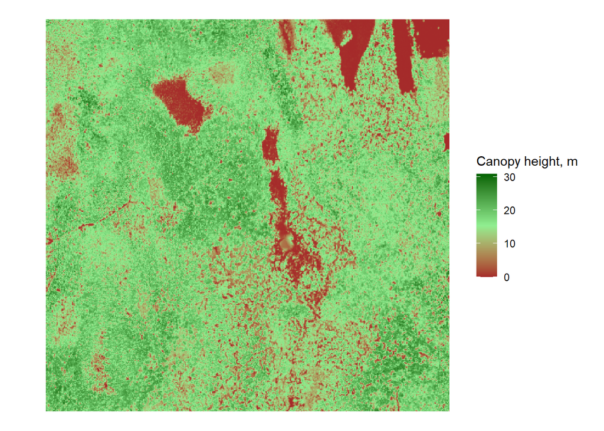

```r
chm_df <- as.data.frame(chm, xy = TRUE)

ggplot() +
  geom_raster(data = chm_df, aes(x = x, y = y, fill = layer)) +
  scale_fill_gradientn(name = 'Canopy height, m',
                       colors = c('brown', 'lightgreen', 'darkgreen')) +
  coord_quickmap() +
  theme_void()
```

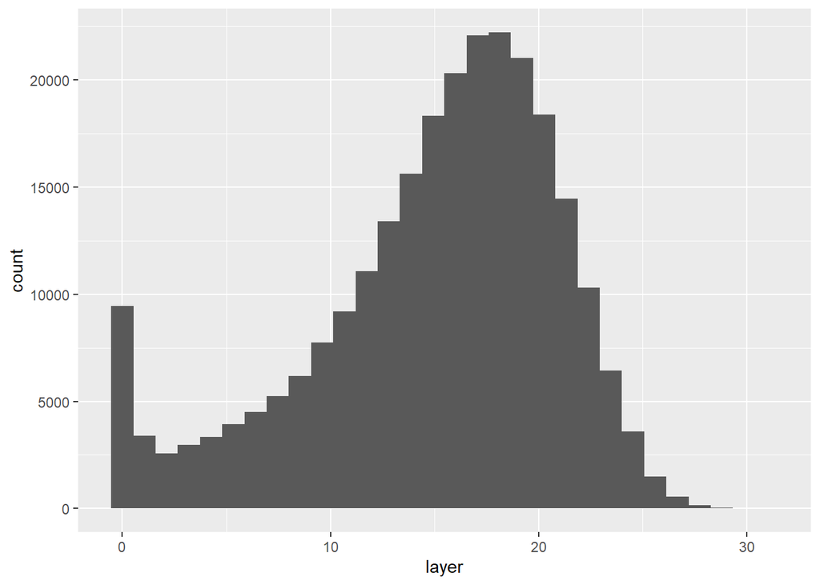

```r
ggplot() +
  geom_histogram(data = chm_df, aes(layer))
```

### Review

- Basic familiarity with raster format
- Introduction to raster math
- Reading, writing, plotting rasters